# DEFENSIVE TRAITS P.lagopus SIBECOL 2025

Andrés Delgado Galán

2025-05-18

### P.lagopus - PRODUCCIÓN DE FLORES

**sqrt(flor) ~ trat + clip + trat:clip**  
n = **16** (muchos 0s quitados)

R² = **-0.1554072**

##### PLflor Post-hoc Comparisons with Tukeys HSD

| contrast | trat | estimate | SE | df | t.ratio | p.value |
| --- | --- | --- | --- | --- | --- | --- |
| no - yes | ex | 0.4401693 | 0.5619519 | 12 | 0.7832864 | 0.4486426 |
| no - yes | gra | 0.3040117 | 0.5803814 | 12 | 0.5238137 | 0.6099464 |

| contrast | clip | estimate | SE | df | t.ratio | p.value |
| --- | --- | --- | --- | --- | --- | --- |
| ex - gra | no | -0.0160829 | 0.5331144 | 12 | -0.0301679 | 0.9764291 |
| ex - gra | yes | -0.1522405 | 0.6069774 | 12 | -0.2508173 | 0.8061985 |

ANOVA Results for PLflor Model

| Response | Predictor | Sum Sq | Df | F value | Pr(>F) |
| --- | --- | --- | --- | --- | --- |
| PL flor | trat | 0.022 | 1 | 0.035 | 0.854 |
| PL flor | clip | 0.543 | 1 | 0.860 | 0.372 |
| PL flor | trat:clip | 0.018 | 1 | 0.028 | 0.869 |
| PL flor | Residuals | 7.579 | 12 | NA | NA |

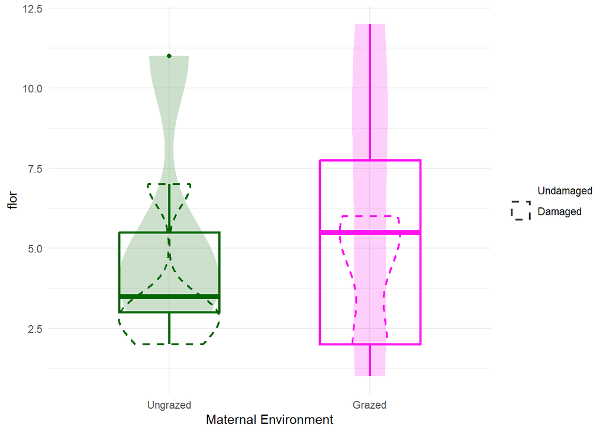

### P.lagopus - PRODUCCIÓN DE FRUTOS

**log(fruto) ~ trat + clip + trat:clip**  
n = **12** (muchos 0s quitados)

R² = **-0.2366664**

##### PLfruto Post-hoc Comparisons with Tukeys HSD

| contrast | trat | estimate | SE | df | t.ratio | p.value |
| --- | --- | --- | --- | --- | --- | --- |
| no - yes | ex | 0.4479399 | 0.6074903 | 8 | 0.7373613 | 0.4819666 |
| no - yes | gra | 0.3426365 | 0.6074903 | 8 | 0.5640197 | 0.5881992 |

| contrast | clip | estimate | SE | df | t.ratio | p.value |
| --- | --- | --- | --- | --- | --- | --- |
| ex - gra | no | -0.0385377 | 0.4960138 | 8 | -0.0776948 | 0.9399790 |
| ex - gra | yes | -0.1438410 | 0.7014694 | 8 | -0.2050567 | 0.8426491 |

ANOVA Results for PLfruto Model

| Response | Predictor | Sum Sq | Df | F value | Pr(>F) |
| --- | --- | --- | --- | --- | --- |
| PL fruto | trat | 0.016 | 1 | 0.033 | 0.860 |
| PL fruto | clip | 0.417 | 1 | 0.847 | 0.384 |
| PL fruto | trat:clip | 0.007 | 1 | 0.015 | 0.905 |
| PL fruto | Residuals | 3.936 | 8 | NA | NA |

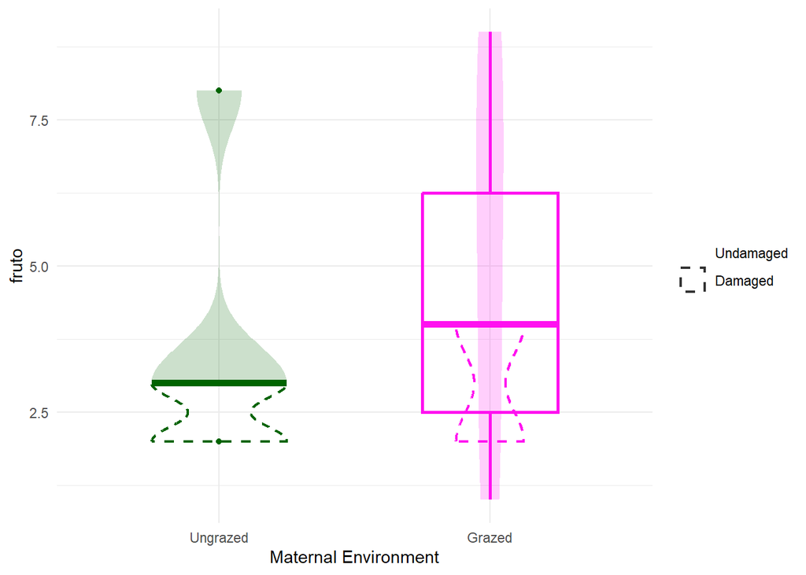

### P.lagopus - PRODUCCIÓN DE HOJAS

**sqrt(hojas) ~ trat + clip + trat:clip**  
n = **52**

R² = **0.0492118**

##### PLhojas Post-hoc Comparisons with Tukeys HSD

| contrast | trat | estimate | SE | df | t.ratio | p.value |
| --- | --- | --- | --- | --- | --- | --- |
| no - yes | ex | -0.6140625 | 0.3360397 | 48 | -1.827351 | 0.0738674 |
| no - yes | gra | 0.4755331 | 0.3212382 | 48 | 1.480313 | 0.1453240 |

| contrast | clip | estimate | SE | df | t.ratio | p.value |
| --- | --- | --- | --- | --- | --- | --- |
| ex - gra | no | -0.4226627 | 0.3152332 | 48 | -1.340794 | 0.1862985 |
| ex - gra | yes | 0.6669329 | 0.3416792 | 48 | 1.951927 | 0.0567941 |

ANOVA Results for PLhojas Model

| Response | Predictor | Sum Sq | Df | F value | Pr(>F) |
| --- | --- | --- | --- | --- | --- |
| PL hojas | trat | 0.080 | 1 | 0.114 | 0.737 |
| PL hojas | clip | 0.026 | 1 | 0.037 | 0.848 |
| PL hojas | trat:clip * | 3.821 | 1 | 5.493 | 0.023 |
| PL hojas | Residuals | 33.389 | 48 | NA | NA |

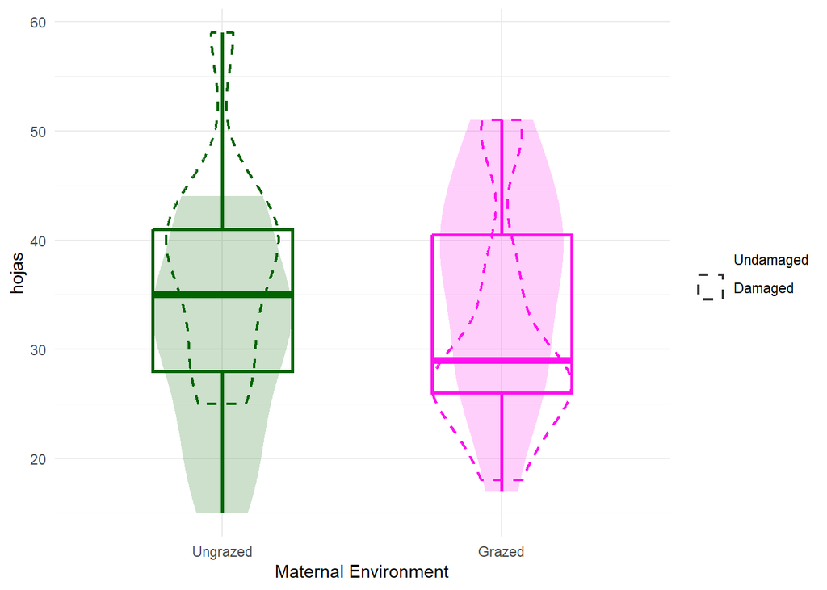

### P.lagopus - ALTURA MÁXIMA

**sqrt(altura) ~ trat + clip + trat:clip**  
n = **17**

R² = **0.107895**

##### PLaltura Post-hoc Comparisons with Tukeys HSD

| contrast | trat | estimate | SE | df | t.ratio | p.value |
| --- | --- | --- | --- | --- | --- | --- |
| no - yes | ex | 0.8922341 | 0.6995227 | 13 | 1.2754898 | 0.2244576 |
| no - yes | gra | 0.7344153 | 0.7615439 | 13 | 0.9643769 | 0.3524546 |

| contrast | clip | estimate | SE | df | t.ratio | p.value |
| --- | --- | --- | --- | --- | --- | --- |
| ex - gra | no | -0.5611301 | 0.6995227 | 13 | -0.8021614 | 0.4368785 |
| ex - gra | yes | -0.7189490 | 0.7615439 | 13 | -0.9440677 | 0.3623511 |

ANOVA Results for PLaltura Model

| Response | Predictor | Sum Sq | Df | F value | Pr(>F) |
| --- | --- | --- | --- | --- | --- |
| PL altura | trat | 1.644 | 1 | 1.511 | 0.241 |
| PL altura | clip | 2.755 | 1 | 2.534 | 0.135 |
| PL altura | trat:clip | 0.025 | 1 | 0.023 | 0.881 |
| PL altura | Residuals | 14.136 | 13 | NA | NA |

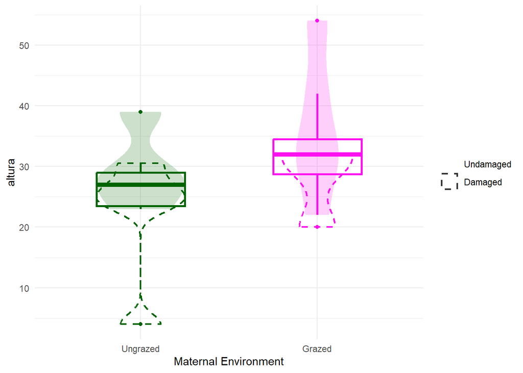

### P.lagopus - SEMILLAS/FRUTO

**sqrt(seedfruto) ~ trat + clip + trat:clip**  
n = **9**

R² = **-0.5144699**

##### PLseedfruto Post-hoc Comparisons with Tukeys HSD

| contrast | trat | estimate | SE | df | t.ratio | p.value |
| --- | --- | --- | --- | --- | --- | --- |
| no - yes | ex | -0.6144745 | 2.510700 | 5 | -0.2447423 | 0.8163828 |
| no - yes | gra | 0.8708960 | 2.430975 | 5 | 0.3582497 | 0.7347849 |

| contrast | clip | estimate | SE | df | t.ratio | p.value |
| --- | --- | --- | --- | --- | --- | --- |
| ex - gra | no | -0.1875208 | 2.430975 | 5 | -0.0771381 | 0.9415053 |
| ex - gra | yes | 1.2978497 | 2.510700 | 5 | 0.5169274 | 0.6272513 |

ANOVA Results for PLseedfruto Model

| Response | Predictor | Sum Sq | Df | F value | Pr(>F) |
| --- | --- | --- | --- | --- | --- |
| PL seedfruto | trat | 0.437 | 1 | 0.093 | 0.773 |
| PL seedfruto | clip | 0.036 | 1 | 0.008 | 0.934 |
| PL seedfruto | trat:clip | 0.854 | 1 | 0.181 | 0.688 |
| PL seedfruto | Residuals | 23.639 | 5 | NA | NA |

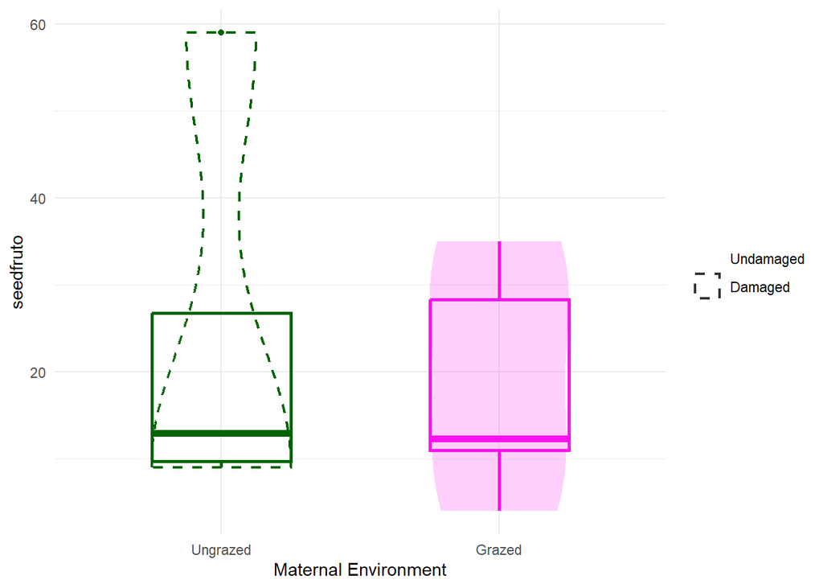

### P.lagopus - PRODUCCIÓN DE SEMILLAS

**sqrt(seedtotal) ~ trat + clip + trat:clip**  
n = **11**

R² = **-0.2278938**

##### PLseedtotal Post-hoc Comparisons with Tukeys HSD

| contrast | trat | estimate | SE | df | t.ratio | p.value |
| --- | --- | --- | --- | --- | --- | --- |
| no - yes | ex | -1.793633 | 4.120277 | 7 | -0.4353186 | 0.6764380 |
| no - yes | gra | 2.156355 | 5.641921 | 7 | 0.3822022 | 0.7136504 |

| contrast | clip | estimate | SE | df | t.ratio | p.value |
| --- | --- | --- | --- | --- | --- | --- |
| ex - gra | no | -4.0755592 | 3.854166 | 7 | -1.0574426 | 0.3254306 |
| ex - gra | yes | -0.1255714 | 5.826951 | 7 | -0.0215501 | 0.9834083 |

ANOVA Results for PLseedtotal Model

| Response | Predictor | Sum Sq | Df | F value | Pr(>F) |
| --- | --- | --- | --- | --- | --- |
| PL seedtotal | trat | 20.346 | 1 | 0.799 | 0.401 |
| PL seedtotal | clip | 0.405 | 1 | 0.016 | 0.903 |
| PL seedtotal | trat:clip | 8.140 | 1 | 0.320 | 0.589 |
| PL seedtotal | Residuals | 178.255 | 7 | NA | NA |

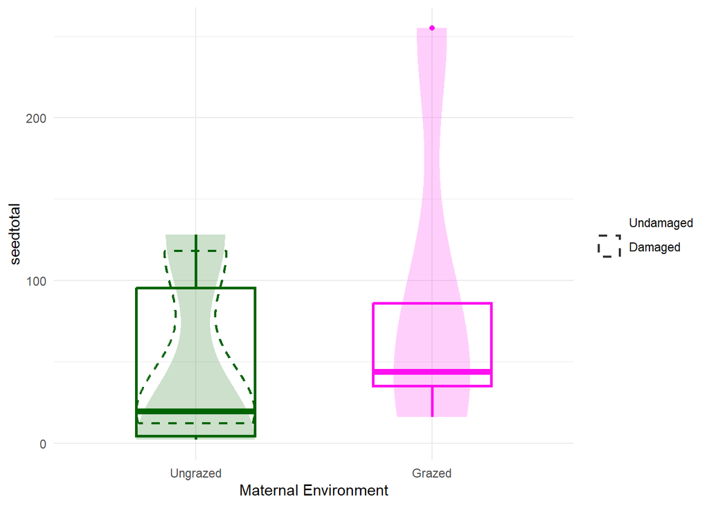

### P.lagopus - PESO MEDIO DE LAS SEMILLAS

**sqrt(massseed) ~ trat + clip + trat:clip**  
n = **10**

R² = **-0.2584553**

##### PLmassseed Post-hoc Comparisons with Tukeys HSD

| contrast | trat | estimate | SE | df | t.ratio | p.value |
| --- | --- | --- | --- | --- | --- | --- |
| no - yes | ex | -0.0031183 | 0.0033718 | 6 | -0.9248188 | 0.3907391 |
| no - yes | gra | -0.0008743 | 0.0041297 | 6 | -0.2117117 | 0.8393403 |

| contrast | clip | estimate | SE | df | t.ratio | p.value |
| --- | --- | --- | --- | --- | --- | --- |
| ex - gra | no | -0.0022441 | 0.0028211 | 6 | -0.7954557 | 0.4566547 |
| ex - gra | yes | 0.0000000 | 0.0045238 | 6 | 0.0000000 | 1.0000000 |

ANOVA Results for PLmassseed Model

| Response | Predictor | Sum Sq | Df | F value | Pr(>F) |
| --- | --- | --- | --- | --- | --- |
| PL massseed | trat | 0 | 1 | 0.456 | 0.525 |
| PL massseed | clip | 0 | 1 | 0.723 | 0.428 |
| PL massseed | trat:clip | 0 | 1 | 0.177 | 0.688 |
| PL massseed | Residuals | 0 | 6 | NA | NA |

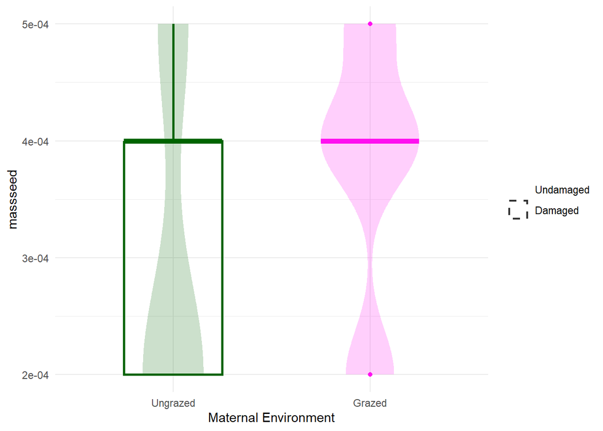

### P.lagopus - SLA

**log(SLA) ~ trat + clip + trat:clip**  
n = **52**

R² = **0.1388944**

##### PLSLA Post-hoc Comparisons with Tukeys HSD

| contrast | trat | estimate | SE | df | t.ratio | p.value |
| --- | --- | --- | --- | --- | --- | --- |
| no - yes | ex | 0.0404852 | 0.0779426 | 48 | 0.5194239 | 0.6058522 |
| no - yes | gra | -0.2326932 | 0.0719098 | 48 | -3.2359026 | 0.0021992 |

| contrast | clip | estimate | SE | df | t.ratio | p.value |
| --- | --- | --- | --- | --- | --- | --- |
| ex - gra | no | 0.0980328 | 0.0732796 | 48 | 1.337791 | 0.1872688 |
| ex - gra | yes | -0.1751456 | 0.0766561 | 48 | -2.284822 | 0.0267843 |

ANOVA Results for PLSLA Model

| Response | Predictor | Sum Sq | Df | F value | Pr(>F) |
| --- | --- | --- | --- | --- | --- |
| PL SLA | trat | 0.014 | 1 | 0.374 | 0.544 |
| PL SLA | clip * | 0.149 | 1 | 4.105 | 0.048 |
| PL SLA | trat:clip * | 0.240 | 1 | 6.636 | 0.013 |
| PL SLA | Residuals | 1.737 | 48 | NA | NA |

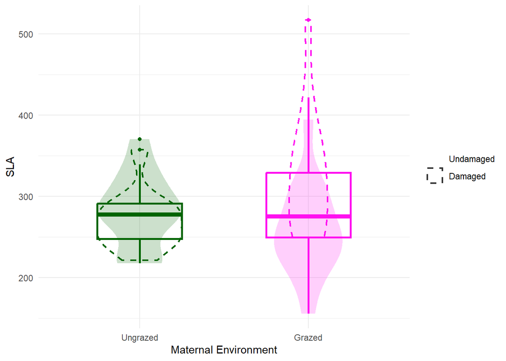

### P.lagopus - LDMC

**sqrt(LDMC) ~ trat + clip + trat:clip**  
n = **52**

R² = **0.0855524**

##### PLLDMC Post-hoc Comparisons with Tukeys HSD

| contrast | trat | estimate | SE | df | t.ratio | p.value |
| --- | --- | --- | --- | --- | --- | --- |
| no - yes | ex | 0.0010768 | 0.0105300 | 48 | 0.1022594 | 0.9189768 |
| no - yes | gra | 0.0252277 | 0.0097489 | 48 | 2.5877441 | 0.0127432 |

| contrast | clip | estimate | SE | df | t.ratio | p.value |
| --- | --- | --- | --- | --- | --- | --- |
| ex - gra | no | -0.0046727 | 0.010147 | 48 | -0.4604987 | 0.6472378 |
| ex - gra | yes | 0.0194782 | 0.010147 | 48 | 1.9196058 | 0.0608622 |

ANOVA Results for PLLDMC Model

| Response | Predictor | Sum Sq | Df | F value | Pr(>F) |
| --- | --- | --- | --- | --- | --- |
| PL LDMC | trat | 0.001 | 1 | 1.064 | 0.307 |
| PL LDMC | clip · | 0.003 | 1 | 3.874 | 0.055 |
| PL LDMC | trat:clip · | 0.002 | 1 | 2.832 | 0.099 |
| PL LDMC | Residuals | 0.032 | 48 | NA | NA |

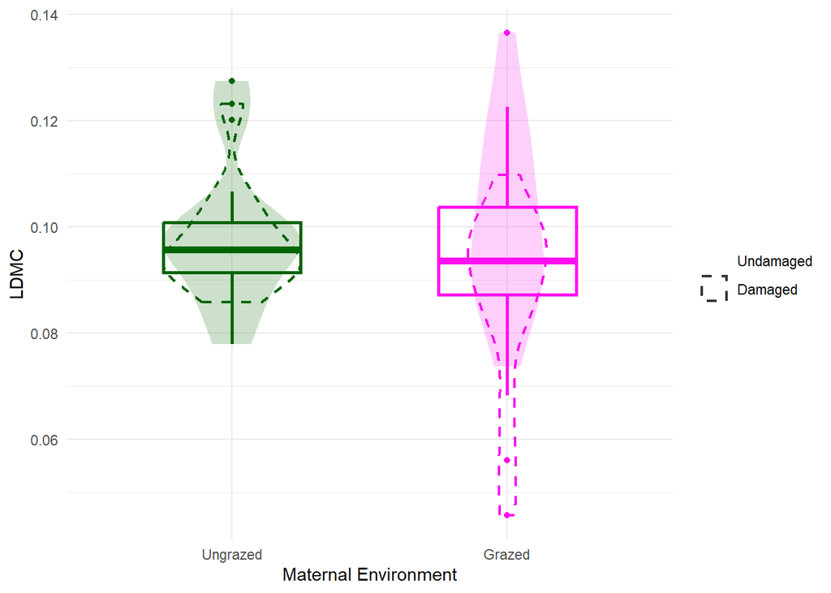

### P.lagopus - ÁREA FOLIAR

**sqrt(area.m) ~ trat + clip + trat:clip**  
n = **53**

R² = **-0.0506055**

##### PLarea.m Post-hoc Comparisons with Tukeys HSD

| contrast | trat | estimate | SE | df | t.ratio | p.value |
| --- | --- | --- | --- | --- | --- | --- |
| no - yes | ex | 0.1036422 | 0.2084829 | 49 | 0.4971253 | 0.6213240 |
| no - yes | gra | 0.0696054 | 0.1968402 | 49 | 0.3536136 | 0.7251455 |

| contrast | clip | estimate | SE | df | t.ratio | p.value |
| --- | --- | --- | --- | --- | --- | --- |
| ex - gra | no | -0.0353309 | 0.2005899 | 49 | -0.1761349 | 0.8609139 |
| ex - gra | yes | -0.0693677 | 0.2048778 | 49 | -0.3385807 | 0.7363722 |

ANOVA Results for PLarea.m Model

| Response | Predictor | Sum Sq | Df | F value | Pr(>F) |
| --- | --- | --- | --- | --- | --- |
| PL area.m | trat | 0.036 | 1 | 0.132 | 0.718 |
| PL area.m | clip | 0.097 | 1 | 0.358 | 0.552 |
| PL area.m | trat:clip | 0.004 | 1 | 0.014 | 0.906 |
| PL area.m | Residuals | 13.290 | 49 | NA | NA |

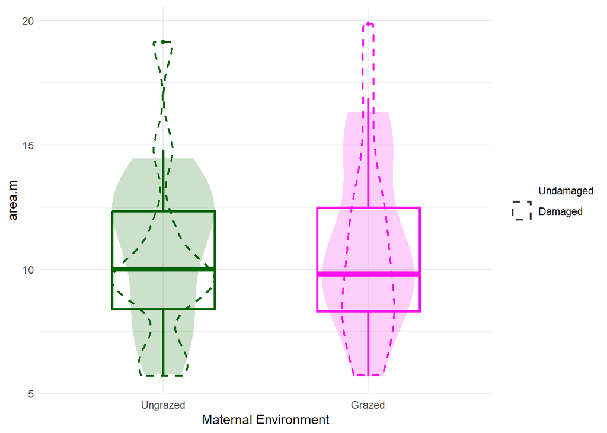

### P.lagopus - TASA FOTOSINTÉTICA

**sqrt(Photosyn) ~ trat + clip + trat:clip**  
n = **30**

```
## We had to increase `err` for some of the quantiles. See fit$calibr$err
## We had to increase `err` for some of the quantiles. See fit$calibr$err
```

R² = **0.2947026**

##### PLPhotosyn Post-hoc Comparisons with Tukeys HSD

| contrast | trat | estimate | SE | df | t.ratio | p.value |
| --- | --- | --- | --- | --- | --- | --- |
| no - yes | ex | -0.2023988 | 0.3028479 | 26 | -0.6683185 | 0.5098205 |
| no - yes | gra | -1.0184905 | 0.2832882 | 26 | -3.5952447 | 0.0013306 |

| contrast | clip | estimate | SE | df | t.ratio | p.value |
| --- | --- | --- | --- | --- | --- | --- |
| ex - gra | no | 0.6819441 | 0.2932312 | 26 | 2.3256194 | 0.0281076 |
| ex - gra | yes | -0.1341476 | 0.2932312 | 26 | -0.4574806 | 0.6511257 |

ANOVA Results for PLPhotosyn Model

| Response | Predictor | Sum Sq | Df | F value | Pr(>F) |
| --- | --- | --- | --- | --- | --- |
| PL Photosyn | trat | 0.560 | 1 | 1.745 | 0.198 |
| PL Photosyn | clip ** | 3.049 | 1 | 9.500 | 0.005 |
| PL Photosyn | trat:clip · | 1.243 | 1 | 3.873 | 0.060 |
| PL Photosyn | Residuals | 8.346 | 26 | NA | NA |

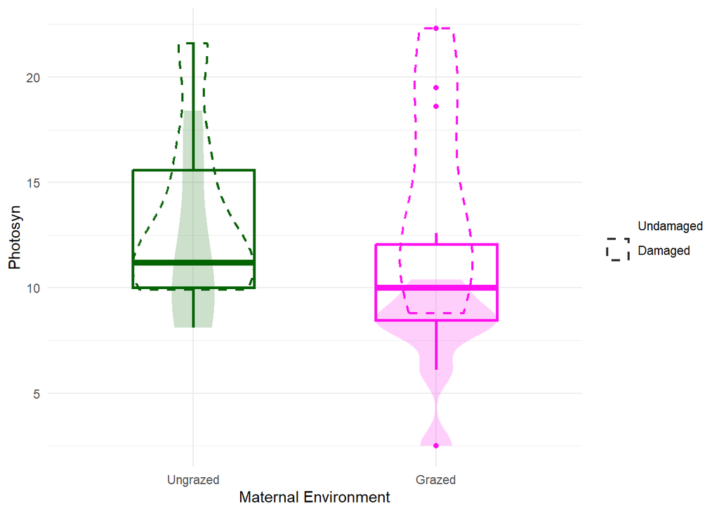

### P.lagopus - CONDUCTANCIA ESTOMÁTICA

**sqrt(Conductance) ~ trat + clip + trat:clip**  
n = **30**

```
## We had to increase `err` for some of the quantiles. See fit$calibr$err
## We had to increase `err` for some of the quantiles. See fit$calibr$err
```

R² = **0.2832913**

##### PLConductance Post-hoc Comparisons with Tukeys HSD

| contrast | trat | estimate | SE | df | t.ratio | p.value |
| --- | --- | --- | --- | --- | --- | --- |
| no - yes | ex | -0.0225087 | 0.0647442 | 26 | -0.3476558 | 0.7308975 |
| no - yes | gra | -0.2084826 | 0.0605627 | 26 | -3.4424256 | 0.0019628 |

| contrast | clip | estimate | SE | df | t.ratio | p.value |
| --- | --- | --- | --- | --- | --- | --- |
| ex - gra | no | 0.0230173 | 0.0626884 | 26 | 0.3671698 | 0.7164640 |
| ex - gra | yes | -0.1629566 | 0.0626884 | 26 | -2.5994719 | 0.0151877 |

ANOVA Results for PLConductance Model

| Response | Predictor | Sum Sq | Df | F value | Pr(>F) |
| --- | --- | --- | --- | --- | --- |
| PL Conductance | trat | 0.037 | 1 | 2.492 | 0.127 |
| PL Conductance | clip * | 0.111 | 1 | 7.571 | 0.011 |
| PL Conductance | trat:clip * | 0.065 | 1 | 4.400 | 0.046 |
| PL Conductance | Residuals | 0.381 | 26 | NA | NA |

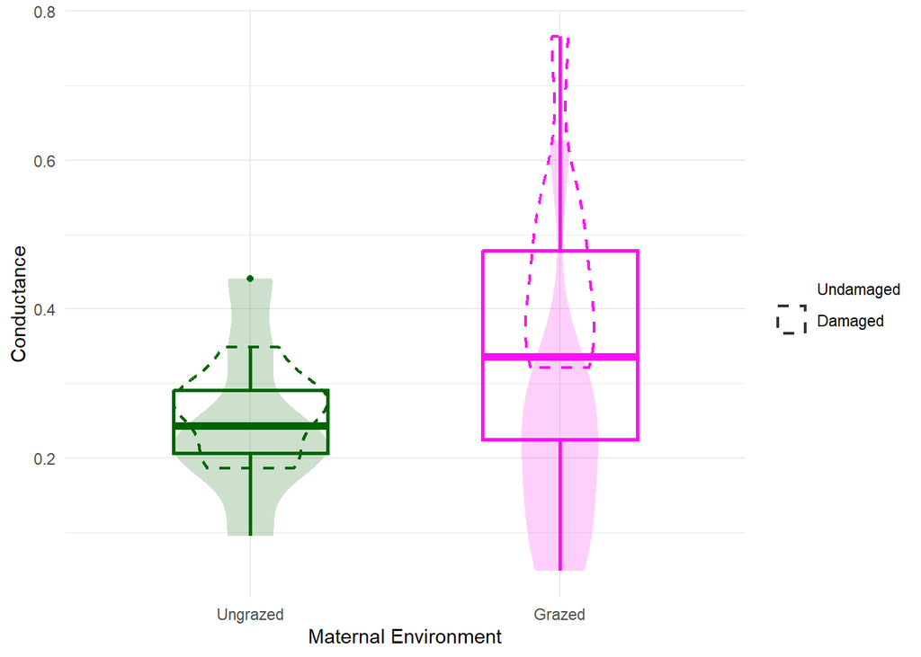

### P.lagopus - EFICIENCIA DEL FOTOSISTEMA II

**log(PhiPS2) ~ trat + clip + trat:clip**  
n = **30**

R² = **0.1197816**

##### PLPhiPS2 Post-hoc Comparisons with Tukeys HSD

| contrast | trat | estimate | SE | df | t.ratio | p.value |
| --- | --- | --- | --- | --- | --- | --- |
| no - yes | ex | -0.2027970 | 0.1880838 | 26 | -1.078227 | 0.2908347 |
| no - yes | gra | -0.3863655 | 0.1759363 | 26 | -2.196054 | 0.0372062 |

| contrast | clip | estimate | SE | df | t.ratio | p.value |
| --- | --- | --- | --- | --- | --- | --- |
| ex - gra | no | 0.2180297 | 0.1821114 | 26 | 1.1972331 | 0.2420178 |
| ex - gra | yes | 0.0344612 | 0.1821114 | 26 | 0.1892317 | 0.8513807 |

ANOVA Results for PLPhiPS2 Model

| Response | Predictor | Sum Sq | Df | F value | Pr(>F) |
| --- | --- | --- | --- | --- | --- |
| PL PhiPS2 | trat | 0.119 | 1 | 0.961 | 0.336 |
| PL PhiPS2 | clip * | 0.678 | 1 | 5.477 | 0.027 |
| PL PhiPS2 | trat:clip | 0.063 | 1 | 0.508 | 0.482 |
| PL PhiPS2 | Residuals | 3.219 | 26 | NA | NA |

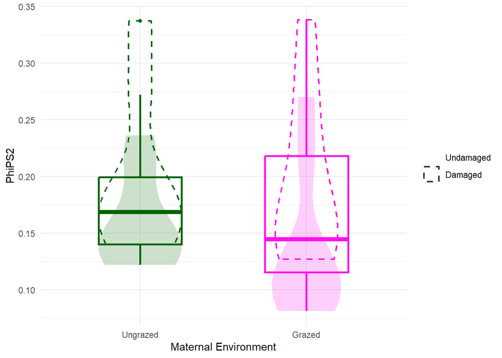

### P.lagopus - FENOLOGÍA DE FLORACIÓN

**sqrt(dias_flor) ~ trat + clip + trat:clip**  
n = **18**

R² = **-0.0024888**

##### PLdias_flor Post-hoc Comparisons with Tukeys HSD

| contrast | trat | estimate | SE | df | t.ratio | p.value |
| --- | --- | --- | --- | --- | --- | --- |
| no - yes | ex | 0.0362635 | 0.6753803 | 14 | 0.0536935 | 0.9579380 |
| no - yes | gra | -0.3533353 | 0.7550981 | 14 | -0.4679330 | 0.6470337 |

| contrast | clip | estimate | SE | df | t.ratio | p.value |
| --- | --- | --- | --- | --- | --- | --- |
| ex - gra | no | 1.032645 | 0.716349 | 14 | 1.4415388 | 0.1714261 |
| ex - gra | yes | 0.643046 | 0.716349 | 14 | 0.8976713 | 0.3845386 |

ANOVA Results for PLdias_flor Model

| Response | Predictor | Sum Sq | Df | F value | Pr(>F) |
| --- | --- | --- | --- | --- | --- |
| PL dias_flor | trat | 3.120 | 1 | 2.736 | 0.120 |
| PL dias_flor | clip | 0.084 | 1 | 0.074 | 0.790 |
| PL dias_flor | trat:clip | 0.169 | 1 | 0.148 | 0.706 |
| PL dias_flor | Residuals | 15.965 | 14 | NA | NA |

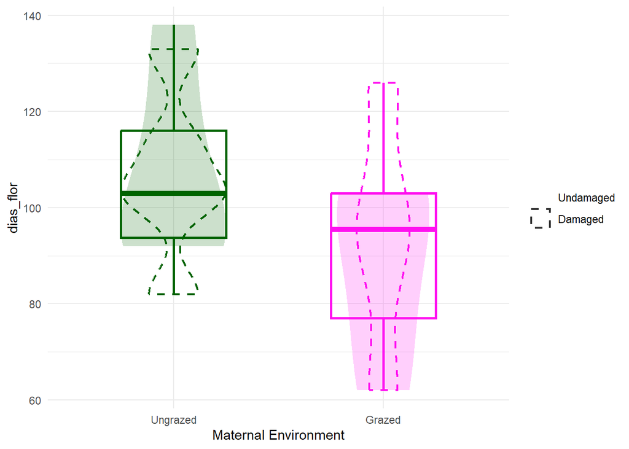

### P.lagopus - FENOLOGÍA DE FRUCTIFICACÓN

**sqrt(dias_fruto) ~ trat + clip + trat:clip**  
n = **16** (no se cumple la homocedasticidad de los residuos)

R² = **-0.0932955**

##### PLdias_fruto Post-hoc Comparisons with Tukeys HSD

| contrast | trat | estimate | SE | df | t.ratio | p.value |
| --- | --- | --- | --- | --- | --- | --- |
| no - yes | ex | 0.0342980 | 0.7785927 | 12 | 0.0440513 | 0.965588 |
| no - yes | gra | -0.2423591 | 0.8041271 | 12 | -0.3013940 | 0.768273 |

| contrast | clip | estimate | SE | df | t.ratio | p.value |
| --- | --- | --- | --- | --- | --- | --- |
| ex - gra | no | 0.8103244 | 0.7386379 | 12 | 1.0970522 | 0.2941454 |
| ex - gra | yes | 0.5336672 | 0.8409762 | 12 | 0.6345806 | 0.5376127 |

ANOVA Results for PLdias_fruto Model

| Response | Predictor | Sum Sq | Df | F value | Pr(>F) |
| --- | --- | --- | --- | --- | --- |
| PL dias_fruto | trat | 1.873 | 1 | 1.545 | 0.238 |
| PL dias_fruto | clip | 0.038 | 1 | 0.032 | 0.862 |
| PL dias_fruto | trat:clip | 0.074 | 1 | 0.061 | 0.809 |
| PL dias_fruto | Residuals | 14.549 | 12 | NA | NA |

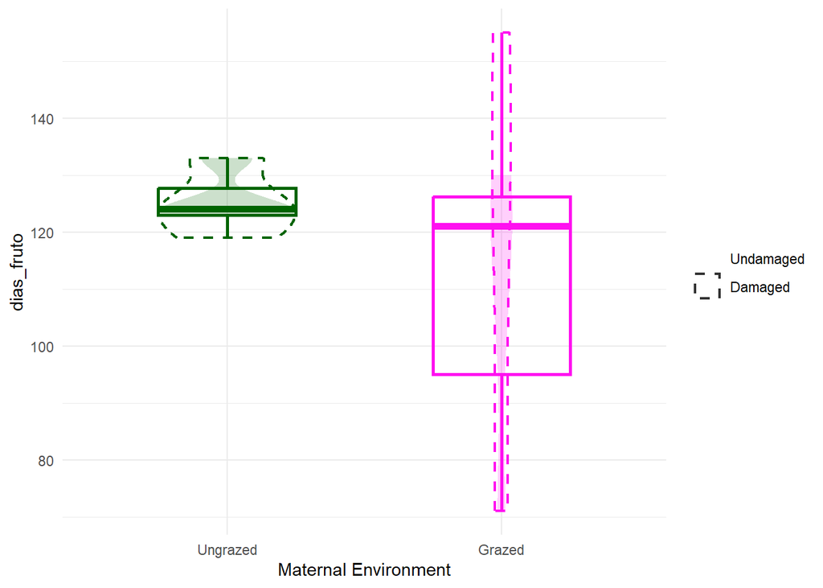

### P.lagopus - PERIODO DE FLORACIÓN

**sqrt(periodo_flor) ~ trat + clip + trat:clip**  
n = **3** no hay modelo que valga. La mayoría de plantas de esta especie ni siquiera empezaron a florecer cuando las cosechamos para la epigenética :(

R² = **NaN**

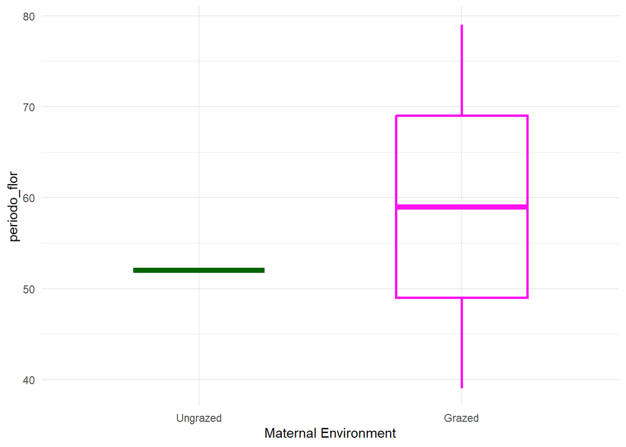

### P.lagopus - PERIODO DE FRUCTIFICACIÓN

**sqrt(periodo_fruto) ~ trat + clip + trat:clip**

n = **3**

R² = **NaN**

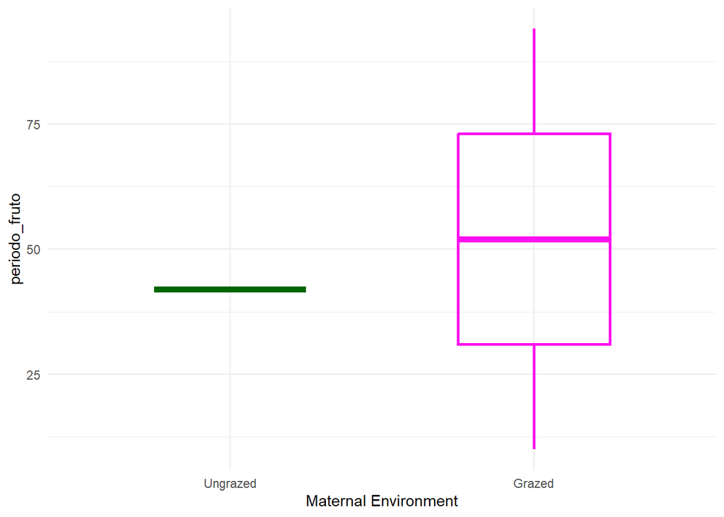

### P.lagopus - ESPERANZA DE VIDA

**sqrt(dias_muerte) ~ trat + clip + trat:clip**  
n = **15**

```
## qu = 0.75, log(sigma) = -2.271608 : outer Newton did not converge fully.
```

R² = **-0.0227273**

##### PLdias_muerte Post-hoc Comparisons with Tukeys HSD

| contrast | trat | estimate | SE | df | t.ratio | p.value |
| --- | --- | --- | --- | --- | --- | --- |
| no - yes | ex | 0.0000000 | 0.0354250 | 11 | 0.000000 | 1.0000000 |
| no - yes | gra | -0.0391638 | 0.0274401 | 11 | -1.427248 | 0.1812739 |

| contrast | clip | estimate | SE | df | t.ratio | p.value |
| --- | --- | --- | --- | --- | --- | --- |
| ex - gra | no | 0.0391638 | 0.0289244 | 11 | 1.354006 | 0.2028976 |
| ex - gra | yes | 0.0000000 | 0.0342238 | 11 | 0.000000 | 1.0000000 |

ANOVA Results for PLdias_muerte Model

| Response | Predictor | Sum Sq | Df | F value | Pr(>F) |
| --- | --- | --- | --- | --- | --- |
| PL dias_muerte | trat | 0.002 | 1 | 1.069 | 0.323 |
| PL dias_muerte | clip | 0.002 | 1 | 1.273 | 0.283 |
| PL dias_muerte | trat:clip | 0.001 | 1 | 0.764 | 0.401 |
| PL dias_muerte | Residuals | 0.018 | 11 | NA | NA |

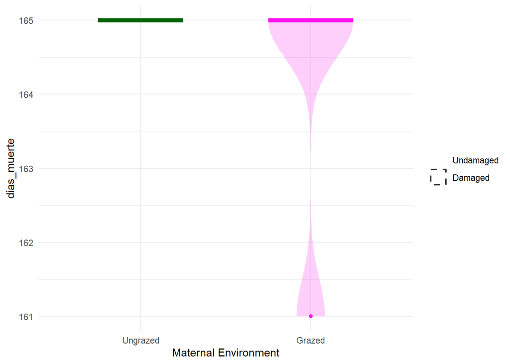

### P.lagopus - FENOLES

**sqrt(fenoles) ~ trat + clip + trat:clip**  
n = **39**

R² = **0.069062**

##### PLfenoles Post-hoc Comparisons with Tukeys HSD

| contrast | trat | estimate | SE | df | t.ratio | p.value |
| --- | --- | --- | --- | --- | --- | --- |
| no - yes | ex | -1.287202 | 0.7754396 | 35 | -1.659965 | 0.1058566 |
| no - yes | gra | -1.126312 | 0.7547575 | 35 | -1.492283 | 0.1445848 |

| contrast | clip | estimate | SE | df | t.ratio | p.value |
| --- | --- | --- | --- | --- | --- | --- |
| ex - gra | no | -0.5411174 | 0.7547575 | 35 | -0.7169421 | 0.4781673 |
| ex - gra | yes | -0.3802269 | 0.7754396 | 35 | -0.4903372 | 0.6269553 |

ANOVA Results for PLfenoles Model

| Response | Predictor | Sum Sq | Df | F value | Pr(>F) |
| --- | --- | --- | --- | --- | --- |
| PL fenoles | trat | 2.086 | 1 | 0.732 | 0.398 |
| PL fenoles | clip * | 14.128 | 1 | 4.960 | 0.032 |
| PL fenoles | trat:clip | 0.063 | 1 | 0.022 | 0.883 |
| PL fenoles | Residuals | 99.690 | 35 | NA | NA |

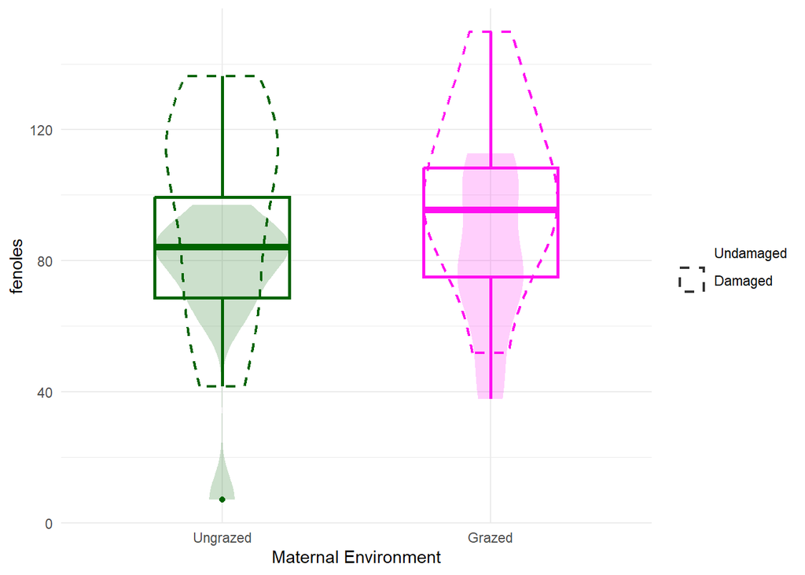